# QC scRNAseq

```r
knitr::opts_chunk$set(echo = T, message = FALSE, warning = FALSE)
stdt<-date()

# Libraries
library(tidyverse)
library(Seurat)

# Input paths
cr.outs <- "/hpc/group/chsi-mic-2022/data/pbmc8k/pbmc8k/outs"
intermeddir <- "/hpc/group/chsi-mic-2022/intermed"

# Output paths
scratchdir <- "/work"
username <- Sys.info()[["user"]]
outdir <- file.path(scratchdir,username,"output")
#dir.create(outdir) # uncomment if not already there
```

**Goal of this workshop:** Learn how to QC scRNAseq data

**What’s covered in this workshop:** - Convert cellranger output to a Seurat object - Calculate mitrochondiral gene percentage - Learn data quality attributes - Exclude data from low-quality cells

**Data source:** scRNA-seq dataset of 8K human peripheral blood mononuclear cells (PBMCs) freely available from 10X Genomics (https://support.10xgenomics.com/single-cell-gene-expression/datasets/2.1.0/pbmc8k)

## Load Seurat objects

We can use code like this to load the cell ranger output and store it in a Seurat object.

```r
Seurat::Read10X_h5(file.path(cr.outs, "filtered_feature_bc_matrix.h5")) %>%
  Seurat::CreateSeuratObject() -> pbmc8k
pbmc8k
```

```
An object of class Seurat
36601 features across 8788 samples within 1 assay
Active assay: RNA (36601 features, 0 variable features)
```

## Add mitrochondiral gene percentage

First, take look at the existing cell-level metadata in one of the seurat objects

```r
head(pbmc8k@meta.data)
```

|  | orig.ident | nCount_RNA | nFeature_RNA |
| --- | --- | --- | --- |
| AAACCTGAGCATCATC-1 | SeuratProject | 3619 | 1631 |
| AAACCTGAGCTAACTC-1 | SeuratProject | 2200 | 1169 |
| AAACCTGAGCTAGTGG-1 | SeuratProject | 5472 | 1917 |
| AAACCTGCACATTAGC-1 | SeuratProject | 3374 | 1343 |
| AAACCTGCACTGTTAG-1 | SeuratProject | 5941 | 2241 |
| AAACCTGCATAGTAAG-1 | SeuratProject | 5369 | 2048 |

orig.ident = sample name nCount_RNA = number of reads per cell nFeature_RNA = number of gene features per cell

```r
curr.count <- pbmc8k@assays$RNA@counts
rownames(curr.count)[1:10]
```

```
 [1] "MIR1302-2HG" "FAM138A"     "OR4F5"       "AL627309.1"  "AL627309.3"  "AL627309.2"  "AL627309.5"  "AL627309.4"  "AP006222.2"
[10] "AL732372.1"
```

```r
rownames(curr.count)[grepl("^MT-", rownames(curr.count))] # these look like mitochondrial genes!
```

```
 [1] "MT-ND1"  "MT-ND2"  "MT-CO1"  "MT-CO2"  "MT-ATP8" "MT-ATP6" "MT-CO3"  "MT-ND3"  "MT-ND4L" "MT-ND4"  "MT-ND5"  "MT-ND6"  "MT-CYB"
```

Add the mitochondrial percentage for 1 seurat object

```r
head(pbmc8k@meta.data)
```

|  | orig.ident | nCount_RNA | nFeature_RNA |
| --- | --- | --- | --- |
| AAACCTGAGCATCATC-1 | SeuratProject | 3619 | 1631 |
| AAACCTGAGCTAACTC-1 | SeuratProject | 2200 | 1169 |
| AAACCTGAGCTAGTGG-1 | SeuratProject | 5472 | 1917 |
| AAACCTGCACATTAGC-1 | SeuratProject | 3374 | 1343 |
| AAACCTGCACTGTTAG-1 | SeuratProject | 5941 | 2241 |
| AAACCTGCATAGTAAG-1 | SeuratProject | 5369 | 2048 |

```r
pbmc8k[["percent.mt"]] <- PercentageFeatureSet(pbmc8k, pattern = "^MT-")
head(pbmc8k@meta.data)
```

|  | orig.ident | nCount_RNA | nFeature_RNA | percent.mt |
| --- | --- | --- | --- | --- |
| AAACCTGAGCATCATC-1 | SeuratProject | 3619 | 1631 | 2.625035 |
| AAACCTGAGCTAACTC-1 | SeuratProject | 2200 | 1169 | 4.363636 |
| AAACCTGAGCTAGTGG-1 | SeuratProject | 5472 | 1917 | 1.608187 |
| AAACCTGCACATTAGC-1 | SeuratProject | 3374 | 1343 | 1.215175 |
| AAACCTGCACTGTTAG-1 | SeuratProject | 5941 | 2241 | 2.794142 |
| AAACCTGCATAGTAAG-1 | SeuratProject | 5369 | 2048 | 3.054573 |

## Initial QC

Number of molecules aka reads detected per cell (nCount)

- A very low number of reads per cell could indicate a sequencing failure.
- A very high number of reads per cell could indicate more than one cell was actually sequenced.

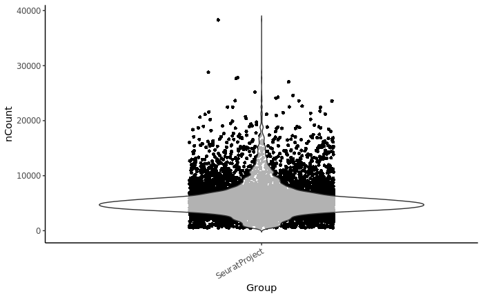

```r
pbmc8k@meta.data %>%
  ggplot(aes(x = orig.ident, y = nCount_RNA))+
    geom_jitter(shape = 16, position = position_jitter(0.2))+
    geom_violin(trim = F, alpha = 0.7) +
  labs(x = "Group", y = "nCount") +
  theme_classic() +
  theme(axis.text.x = element_text(angle = 30, hjust=1),
        strip.text = element_text(size = 6))
```

Number of gene features detected per cell (nFeature)

- A very low number of gene features per cell could indicate a library prep or sequencing failure.

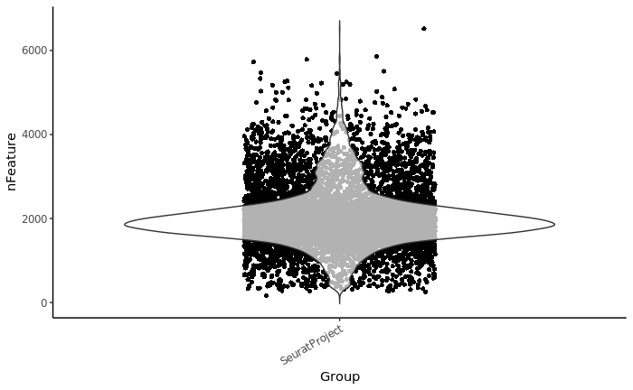

```r
pbmc8k@meta.data %>%
  ggplot(aes(x = orig.ident, y = nFeature_RNA))+
    geom_jitter(shape = 16, position = position_jitter(0.2))+
    geom_violin(trim = F, alpha = 0.7)+
  labs(x = "Group", y = "nFeature") +
  theme_classic() +
  theme(axis.text.x = element_text(angle = 30, hjust=1),
        strip.text = element_text(size = 6))
```

Percentage of mitochondrial genes per cell (MT%)

- A high percentage of mitochondrial genes (MT%) indicates a cell may be dead or dying based on the expectation that, if a cell is ruptured, non-MT genes will leak out first and increase the relative abundance of MT genes.

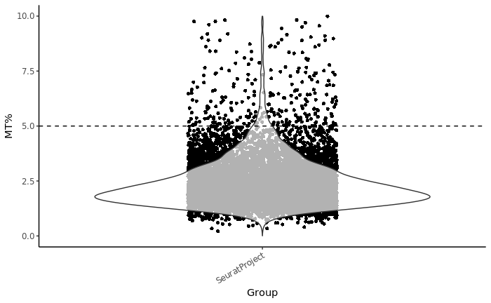

```r
pbmc8k@meta.data %>%
  ggplot(aes(x = orig.ident, y = percent.mt)) +
  geom_jitter(shape=16, position=position_jitter(0.2))+
    geom_violin(trim=FALSE, alpha=0.7)+
  scale_y_continuous(limits = c(0, 10)) +
  labs(x = "Group", y = "MT%") +
  theme_classic() +
  theme(axis.text.x = element_text(angle = 30, hjust=1),
        strip.text = element_text(size = 6)) +
  geom_hline(yintercept = 5, linetype = 2)
```

Correlation between nCounts and nFeatures, colored by MT%

- The number of gene features detected in a cell (nFeatures) tends to increase with library size (nCounts). Divergence from this correlation could indicate low-quality data, e.g. often observed in high MT% cells.

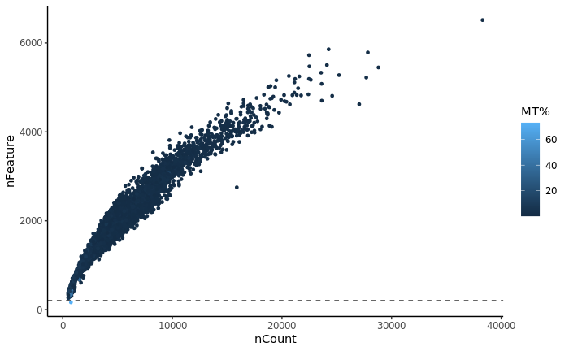

```r
pbmc8k@meta.data %>%
  ggplot(aes(x = nCount_RNA, y = nFeature_RNA,
                color = percent.mt))+
    geom_point(size = 1)+
    labs(x = "nCount", y = "nFeature", color = "MT%") +
  theme_classic() +
  geom_hline(yintercept = 200, linetype = 2)
```

## Filter cells

“Low-quality cells that had less than 200 expressed genes and more than 5% mitochondrial genes were filtered out.”

### nCount

```r
cl <- 6 # min number of total reads per cell (nCount is analogous to library size or total number of reads)
ch <- 11 # max number of total reads per cell
```

Filter out cells with log(nCount) $>$ `ch` & $<$ `cl`

- Note: Different y-axis scales

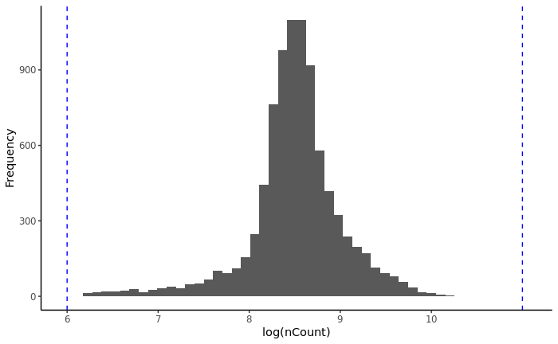

```r
pbmc8k@meta.data %>%
  ggplot(aes(x = log(nCount_RNA))) +
  geom_histogram(bins = 50) +
  geom_vline(xintercept = c(cl, ch),
             color = "blue", linetype = "dashed") +
  labs(x = "log(nCount)", y = "Frequency") +
  scale_x_continuous(breaks = seq(0, 10, 1)) +
  theme_classic()
```

### nFeature

```r
fl <- 5.5 # min number of gene features per cell
```

Filtering out cells with log(nFeature) $<$ `fl`

- Note: Different y-axis scales

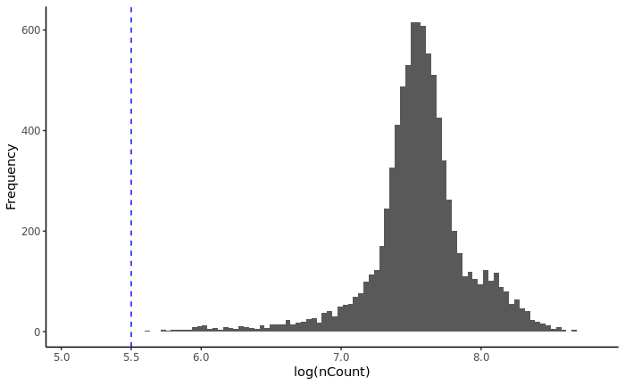

```r
pbmc8k@meta.data %>%
  ggplot(aes(x = log(nFeature_RNA))) +
  geom_histogram(bins = 100) +
  geom_vline(xintercept = fl,
             color = "blue", linetype = "dashed") +
  scale_x_continuous(breaks = c(seq(0, 20, 1), fl)) +
  labs(x = "log(nCount)", y = "Frequency") +
  theme_classic()
```

### MT%

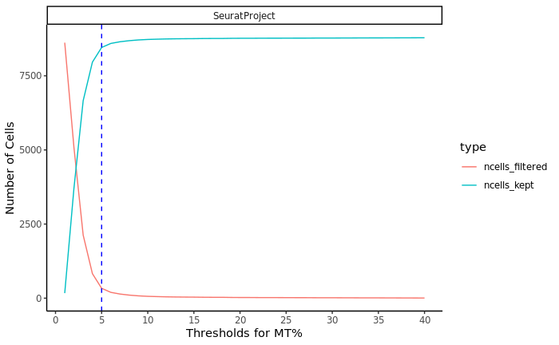

```r
tmp <- lapply(seq(1, 40, 1), function(v){

  pbmc8k@meta.data %>%
    group_by(orig.ident) %>%
    summarize(threshold = v,
              ncells_kept = sum(percent.mt < v),
              ncells_filtered = sum(percent.mt >= v))
}) %>%
  bind_rows() %>%
  pivot_longer(cols = c("ncells_filtered", "ncells_kept"),
               names_to = "type",
               values_to = "ncells")

ml <- 5
ggplot(tmp, aes(x=threshold, y=ncells, colour=type))+
    geom_line() +
  geom_vline(xintercept = ml, color = "blue", linetype = "dashed") +
  scale_x_continuous(breaks = seq(0, 40, by = 5)) +
    labs(x="Thresholds for MT%", y="Number of Cells")+
  facet_wrap(~orig.ident, nrow = 3,
             scales = "free_y")+
  theme_classic()
```

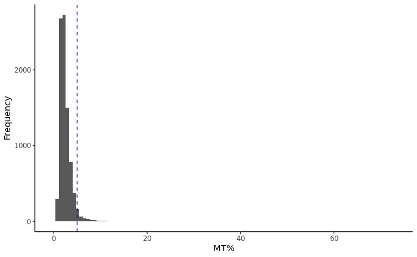

```r
pbmc8k@meta.data %>%
  ggplot(aes(x = percent.mt)) +
  geom_histogram(bins = 100) +
  geom_vline(xintercept = ml,
             color = "blue", linetype = "dashed") +
  # scale_x_continuous(breaks = c(seq(2, 14, 2), fl)) +
  labs(x = "MT%", y = "Frequency") +
  theme_classic()
```

### Do the filtering

Pre

```r
nrow(pbmc8k@meta.data)
```

```
[1] 8788
```

Filter

```r
seu_filt <- function(seuobj){
  seuobj_filt <- subset(seuobj,
         nCount_RNA > exp(cl) &
         nCount_RNA < exp(ch) &
         nFeature_RNA > exp(fl) &
         percent.mt < ml)
  return(seuobj_filt)
}

pbmc8k.filt <- seu_filt(seuobj = pbmc8k)
```

Post

```r
nrow(pbmc8k.filt@meta.data)
```

```
[1] 8456
```

Number of cells removed by filtering

```r
nrow(pbmc8k@meta.data) - nrow(pbmc8k.filt@meta.data)
```

```
[1] 332
```

## Final QC

nCount

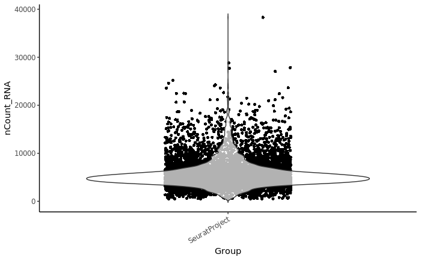

```r
pbmc8k.filt@meta.data %>%
  ggplot(aes(x = orig.ident, y = nCount_RNA))+
    geom_jitter(shape = 16, position = position_jitter(0.2))+
    geom_violin(trim = F, alpha = 0.7) +
  labs(x = "Group") +
  theme_classic() +
  theme(axis.text.x = element_text(angle = 30, hjust=1))
```

nFeature

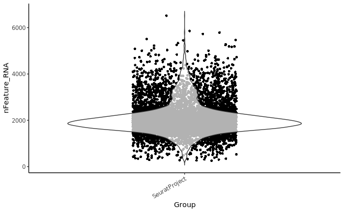

```r
pbmc8k.filt@meta.data %>%
  ggplot(aes(x = orig.ident, y = nFeature_RNA)) +
    geom_jitter(shape = 16, position = position_jitter(0.2))+
    geom_violin(trim = F, alpha = 0.7)+
  labs(x = "Group") +
  theme_classic() +
  theme(axis.text.x = element_text(angle = 30, hjust=1))
```

MT%

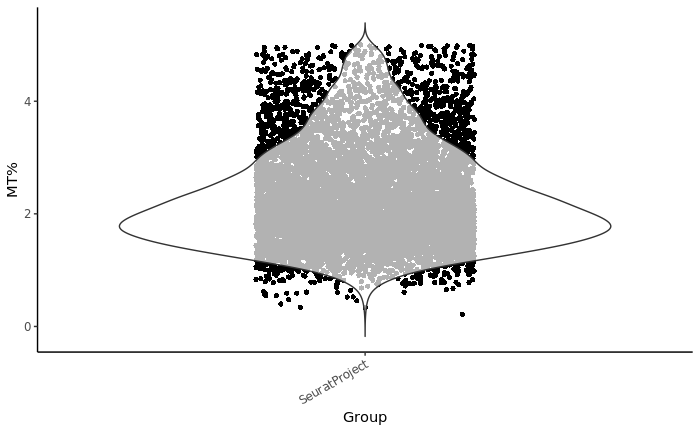

```r
pbmc8k.filt@meta.data %>%
  ggplot(aes(x = orig.ident, y = percent.mt)) +
  geom_jitter(shape=16, position=position_jitter(0.2))+
    geom_violin(trim=FALSE, alpha=0.7)+
  labs(x = "Group", y = "MT%") +
  theme_classic()+
  theme(axis.text.x = element_text(angle = 30, hjust=1))
```

Correlation between nCounts and nFeatures, colored by MT%

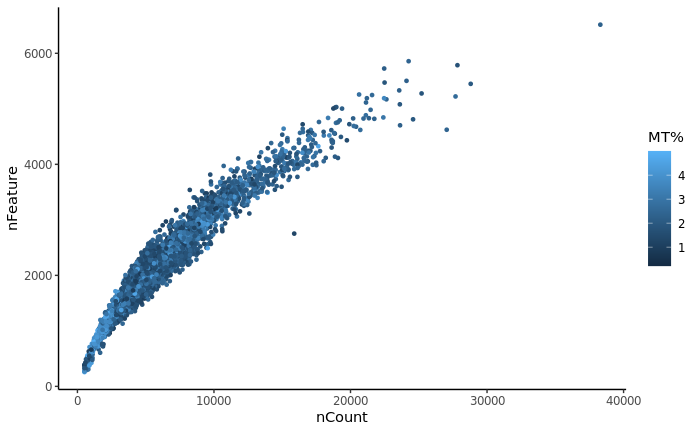

```r
pbmc8k.filt@meta.data %>%
  ggplot(aes(x = nCount_RNA, y = nFeature_RNA,
                color = percent.mt))+
    geom_point(size = 1)+
    labs(x = "nCount", y = "nFeature", color = "MT%") +
  theme_classic()
```

```r
print(paste("Start Time:  ",stdt))
```

```
[1] "Start Time:   Fri May 20 18:38:23 2022"
```

```r
print(paste("End Time:  ",date()))
```

```
[1] "End Time:   Fri May 20 18:38:35 2022"
```